# Lab5

#### Region growing and tagging

**Exercise 2 [0.25 pts]:** Using the previously obtained clean mask, segment each lung:

1. Apply region growing to separate the different regions in the mask. Use the flood_fill() from skimage.segmentation implementation.
2. Tag the lungs as follows: left lung = 1; right lung = 2; background = 0 (see Figure next). Save the resulting image.

[figure not shown]

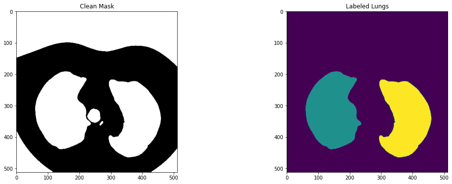

```
True
```

```python
###  YOUR CODE
from skimage.segmentation import flood_fill

# Aplica flood_fill para etiquetar los pulmones
#Left lung
labeled_lungs=flood_fill(out_mask, (300,150), 1)

#Rihgt lung
labeled_lungs=flood_fill(labeled_lungs, (300, 400), 2)

#Background
labeled_lungs=flood_fill(labeled_lungs, (0, 0), 0)
labeled_lungs=flood_fill(labeled_lungs, (500, 50), 0)
labeled_lungs=flood_fill(labeled_lungs, (500, 500), 0)
labeled_lungs=flood_fill(labeled_lungs, (333, 245), 0)
labeled_lungs=flood_fill(labeled_lungs, (358, 272), 0)



# Muestra las imágenes resultantes
fig, ax = plt.subplots(1, 2, figsize=(18, 6))
ax[0].imshow(out_mask, cmap='gray')
ax[0].set_title('Clean Mask')

ax[1].imshow(labeled_lungs)
ax[1].set_title('Labeled Lungs')

plt.show()

cv2.imwrite(images_path+'labeled_lung.png', labeled_lungs)
```

##### To segment as desired, we define a series of points. One in each lung, which will form a region, and the points in all the regions that are not lungs (we have to define several because they are not all interconnected with each other).

Another image processing tool that could have been used to separate the lungs is *'Connected components'*. A connected component consists of the set of pixels/voxels that are linked to each other. See example next.

```
Found 7 connected components
```

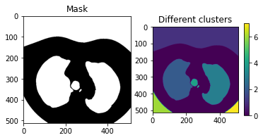

```python
blobs = measure.label(out_mask)         # implementation of the connected components filter. It labels connected regions of an integer array
print('Found', len(np.unique(blobs)) - 1, 'connected components')

plt.figure(figsize=(6, 6))
plt.subplot(1, 2, 1)
plt.imshow(out_mask, cmap='gray'), plt.title('Mask')
plt.subplot(1, 2, 2)
plt.imshow(blobs), plt.title('Different clusters')
plt.colorbar(shrink=.4)
```

```
(<matplotlib.image.AxesImage at 0x7ff2d2532f10>, Text(0.5, 1.0, 'Right lung'))
```

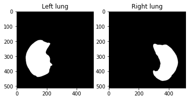

```python
# Now we can find out which labels correspond to the lungs by directly inspecting the mask or using a condition (e.g. biggest/smallest cluster?;
# condition relating to location (not region including any border, etc.))

left_lung_label = 2        # is it this label??
right_lung_label = 3

left_lung = out_mask.copy()
left_lung[np.where(blobs != left_lung_label)] = 0

right_lung = out_mask.copy()
right_lung[np.where(blobs != right_lung_label)] = 0

plt.figure(figsize=(6, 6))
plt.subplot(1, 2, 1)
plt.imshow(left_lung, 'gray'), plt.title('Left lung')
plt.subplot(1, 2, 2)
plt.imshow(right_lung, 'gray'), plt.title('Right lung')
```

#### Image segmentation, real examples

**Exercise 3 [0.50 pts]:** Segment the Aorta from 'CT.png' (see Figure next) and compute its area:

1. Segment the brightest regions using intensity-based thresholding.
2. Apply some of the methods seen today to isolate the Aorta. Explain your choice.
3. Compute the area. The pixel's size is aprox 0.36 $mm^2$.

[figure not shown]

```
Number of white pixels:  7487
Area:  2695.3199999999997 mm2
```

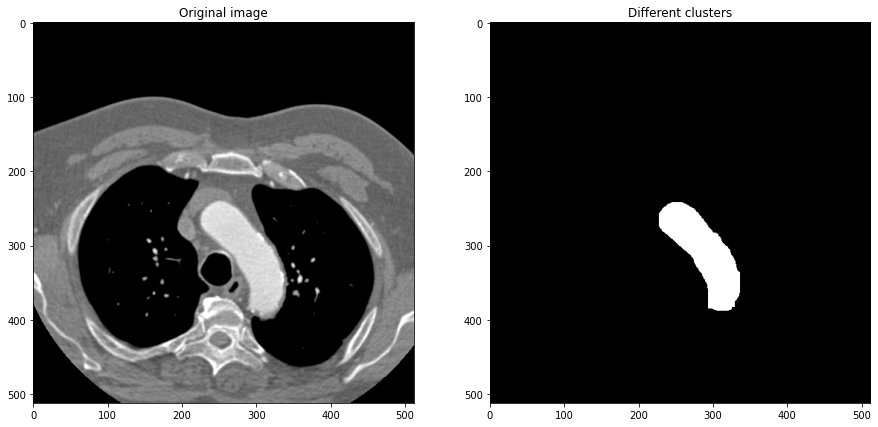

```python
###  YOUR CODE
im_ct = cv2.imread(images_path + 'CT.png', cv2.IMREAD_GRAYSCALE)     # original image for reference

# Threshold the image to get the bones
threshold = 144

# Create a mask with the bones
bones_mask = np.zeros_like(im_ct)
bones_mask[np.where(im_ct > threshold)] = 1

# Apply opening to remove the small white noise in the bones
bones_mask=opening(bones_mask, np.ones((15,15)))


# Count the number of white pixels in the mask
white_pixel_count = cv2.countNonZero(bones_mask)

# Calculate the area of the bones
area=white_pixel_count*0.36

# Show the results
print('Number of white pixels: ', white_pixel_count)
print('Area: ',area, 'mm2')
plt.figure(figsize=(15, 15))
plt.subplot(1, 2, 1)
plt.imshow(im_ct, 'gray'), plt.title('Original image')
plt.subplot(1, 2, 2)
plt.imshow(bones_mask, 'gray'), plt.title('Different clusters')
plt.show()
```

##### After isolating the image of the aorta, we calculate the blank pixels and the area they occupy. Even so, this area may be smaller than it actually is because some pixels corresponding to the aorta have been lost due to the filtering process.

**Exercise 4 [0.50 pts]:** Automatically estimate the number of cells in 'cells.png' (see Figure next). Note that some cells are joined together.

[figure not shown]

```
Found 93 connected components
```

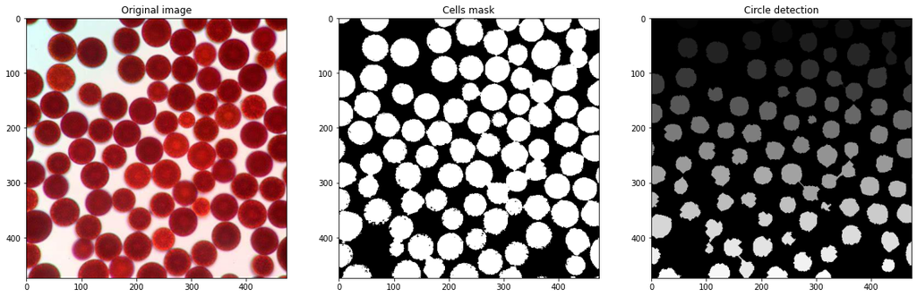

```python
# First binarize the image.
im_cells = plt.imread(images_path + '/cells.jpg')
cells_mask = im_cells[:, :, 2] < 50
cells_mask = cells_mask.astype(int)


img=cells_mask

# Apply morphological operations to separate the cells
img=erosion(img, se5_cross)
img=erosion(img, se5_cross)
img=opening(img, se5_cross)
img=erosion(img, se5_cross)

# Apply connected components to detect the cells
blobs = measure.label(img)
print('Found', len(np.unique(blobs)) - 1, 'connected components')

# Show the results
fig, ax = plt.subplots(1, 3, figsize=(20, 20))
ax[0].imshow(im_cells)
ax[0].set_title('Original image')
ax[1].imshow(cells_mask, cmap='gray')
ax[1].set_title('Cells mask')
ax[2].imshow(blobs, cmap='gray')
ax[2].set_title('Circle detection')
```

##### First, we apply a series of erosions and opening, in order to separate the different circles so that we can count them later. Once separated, we count them by counting the connected components.